# Statistical machine learning, Lab 13

# Classification and regression with linear SVM-s

The aim of this lab is to learn to use maximal margin linear classifiers, support vector classifiers and $\varepsilon$-insensitive linear regression.

## R packages we use in the lab

We are going to use `tidymodels` framework and `kernlab` package.

## Datasets of the lab

We are going to use `iris` and `Heart` dataset (first is loaded into R by default, the second one is available from Moodle) for classification.

### Exercise 1

Use `set.seed(20241128)` to fix randomness. After that, form a 5-fold cross-validation data set (considering the full data set as training data). Then find the cross-validation accuracy of Random Forest method (used with default parameters) for predicting the class of `AHD`

```r
Heart=read_delim("Heart.csv",show_col_types = FALSE,col_select=-1)
set.seed(20241128)
cv1=vfold_cv(Heart,v=5)
rec1=recipe(AHD~.,data=Heart)|>step_impute_mode(Thal)|>step_impute_mean(Ca)
```

```r
#models
wf1=workflow()|>add_recipe(rec1)|>add_model(rand_forest(mode="classification"))
cv_results_randforest=wf1|>fit_resamples(cv1)|>collect_metrics()
cv_results_randforest
```

| .metric | .estimator | mean | n | std_err | .config |
| --- | --- | --- | --- | --- | --- |
| accuracy | binary | 0.8184153 | 5 | 0.02896685 | Preprocessor1_Model1 |
| brier_class | binary | 0.1345524 | 5 | 0.01221752 | Preprocessor1_Model1 |
| roc_auc | binary | 0.9027509 | 5 | 0.01594127 | Preprocessor1_Model1 |

## Linear support vector classifier

There are different packages which can be used for fitting support vector methods to data. We are going to consider the package `kernlab` (an universal package for SVMs). Alternatives are `LiblineaR` (linear svm-s),`e1071` and `klaR` package which use different computational engines (and may be more efficient in certain situations).

There are different but mathematically equivalent ways to specify the same problem of finding a classifier which reduces to the maximal margin classifier in the case of separable classes. The difference is in the meaning of the penalty term. We consider the formulation where penalty $C$ denotes the coefficient of the cost of the value of the underlying function to be less then 1 for observations in the class 1 ($C$ is multiplied by the amount the value is smaller than 1) or greater than -1 in the case of observations from class -1. An alternative is to formulate problem with parameter $\nu$ which is always between 0 and 1 and is related to the proportion of observations taken into account when determining the classification boundary (proportion of support vectors). More detailed information is available from various text books, and overview is also given in http://is.tuebingen.mpg.de/fileadmin/user_upload/files/publications/pdf3353.pdf

As the coefficients of a given linear function depend on units of measurement and the values of coefficients are important in support vector classification, the results can be quite different for normalized and unnormalized data. Usually it is a good idea to scale the data. The function `ksvm` from the `kernlab` package scales both predictors and in the case of regression also response by default.

Linear SVM models are fitted in the tidymodels framework by specifying the model with `svm_linear` and in order to use `kernlab` package for fitting, the engine should also be indicated by `engine="kernlab"`.

### Exercise 2

Add a variable `setose` with values `Yes` and `No` (according to the value of the `Species` variable) to `iris` dataset, name the modified dataset to `ex1_data`. Use tidymodels framework to fit SVM models to `setosa` using `Sepal.Length` and `Petal.Length` as predictors, using `cost` values 0.1,1,10 and produce corresponding classification plots with `kernlab::plot(extract_fit_engine(model),data=ex1_data)` command. What can you say about how `cost` parameter influences the number of support vectors?

```r
katse <- iris|>mutate(y=if_else(Species=="setosa","Yes","No"))
rec =recipe(y~Petal.Length+Sepal.Length,data=katse)
wf=workflow()|>add_recipe(rec)|>add_model(svm_linear(mode="classification",engine="kernlab",cost=10))
wf_fitted =wf|>fit(katse)
```

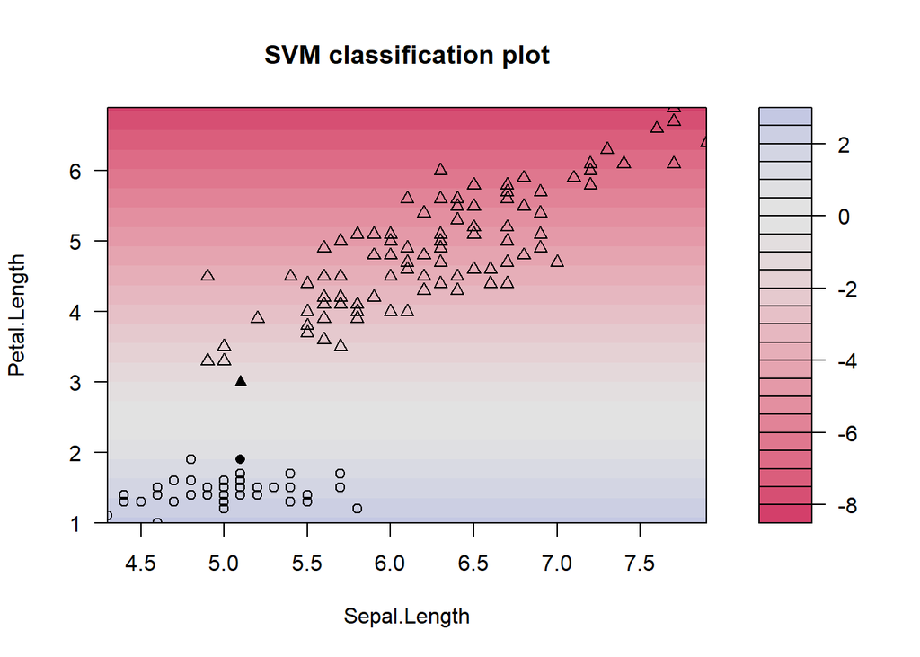

```r
kernlab::plot(extract_fit_engine(wf_fitted),data=katse)
```

### Exercise 3

Use tuning to find the best linear support vector classifier for `AHD` in the case of `Heart` data both for unscaled and scaled predictors by using `kernlab` engine. Fit the best model to the full `Heart` data set and produce a graph with respect to variables `Chol` and `MaxHR`, which shows observations, actual value of `AHD` by shape and predicted value of `AHD` by color.

```r
#scaled, kernlab
wf2.1_tune=workflow()|>add_recipe(rec1)|>add_model(svm_linear(mode="classification",cost=tune(),engine="kernlab"))
Cgrid=data.frame(cost=10^seq(-3,3,length.out=5))
res2.1_tune=tune_grid(wf2.1_tune,cv1,grid=Cgrid,metrics=metric_set(accuracy))
show_best(res2.1_tune,metric="accuracy")
```

| cost | .metric | .estimator | mean | n | std_err | .config |
| --- | --- | --- | --- | --- | --- | --- |
| 3.162278e-02 | accuracy | binary | 0.8185246 | 5 | 0.02584336 | Preprocessor1_Model2 |
| 1.000000e+00 | accuracy | binary | 0.8151913 | 5 | 0.02557946 | Preprocessor1_Model3 |
| 3.162278e+01 | accuracy | binary | 0.8151366 | 5 | 0.02720790 | Preprocessor1_Model4 |
| 1.000000e+03 | accuracy | binary | 0.8151366 | 5 | 0.02720790 | Preprocessor1_Model5 |
| 1.000000e-03 | accuracy | binary | 0.6213661 | 5 | 0.05888016 | Preprocessor1_Model1 |

```r
wf2.2_tune=workflow()|>add_recipe(rec1)|>add_model(svm_linear(mode="classification",cost=tune())|>set_engine("kernlab",scaled=FALSE))
Cgrid=data.frame(cost=10^seq(-3,3,length.out=5))
res2.2_tune=tune_grid(wf2.2_tune,cv1,grid=Cgrid,metrics=metric_set(accuracy))
show_best(res2.2_tune,n=5)
```

| cost | .metric | .estimator | mean | n | std_err | .config |
| --- | --- | --- | --- | --- | --- | --- |
| 1.000000e+00 | accuracy | binary | 0.8151913 | 5 | 0.02766622 | Preprocessor1_Model3 |
| 3.162278e+01 | accuracy | binary | 0.8151366 | 5 | 0.02406290 | Preprocessor1_Model4 |
| 3.162278e-02 | accuracy | binary | 0.8085246 | 5 | 0.03058931 | Preprocessor1_Model2 |
| 1.000000e+03 | accuracy | binary | 0.7951913 | 5 | 0.03419665 | Preprocessor1_Model5 |
| 1.000000e-03 | accuracy | binary | 0.7129508 | 5 | 0.04158912 | Preprocessor1_Model1 |

```r
wf2.1_fitted=finalize_workflow(wf2.1_tune,select_best(res2.1_tune,metric="accuracy"))|>fit(Heart)
```

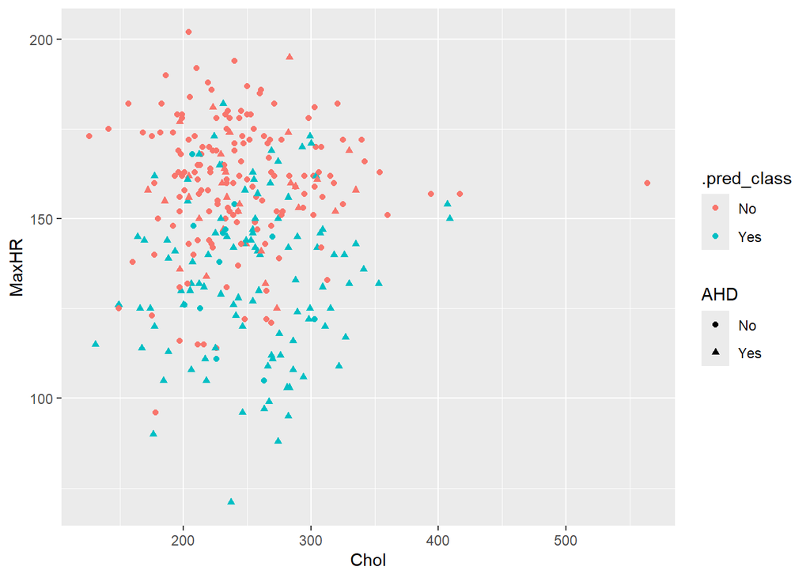

```r
ggplot(augment(wf2.1_fitted,new_data=Heart))+geom_point(aes(x=Chol,y=MaxHR,shape=AHD,color=.pred_class))
```

# Classification with SVM-s using polynomial and radial basis function kernels

### Exercise 4

Divide the Heart dataset to training (70%) and validation sets by stratifying with respect ot `AHD`. Find the best linear linear SVM classifier for `AHD` in terms of `Chol` and `MaxHR` and produce plots about it’s performance on the training and validation sets.

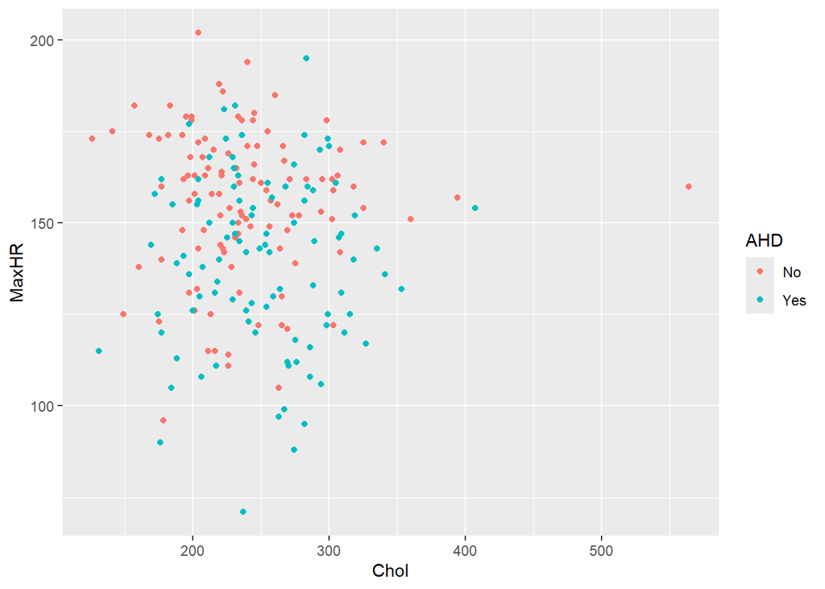

```r
set.seed(20241128)
splitted=mc_cv(Heart,prop=0.7,strata=AHD,times=1)
train=training(splitted$splits[[1]])
test=testing(splitted$splits[[1]])
ggplot(train)+geom_point(aes(x=Chol,y=MaxHR,color=AHD))
```

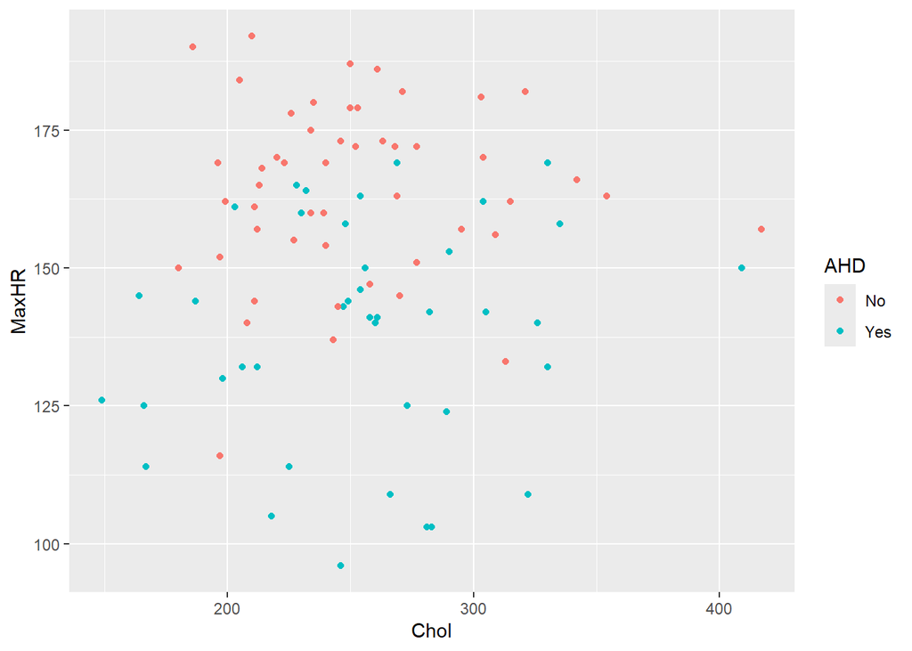

```r
ggplot(test)+geom_point(aes(x=Chol,y=MaxHR,color=AHD))
```

```r
rec4=recipe(AHD~Chol+MaxHR,data=train)
wf4_tune=workflow()|>add_recipe(rec4)|>add_model(svm_linear(mode="classification",cost=tune::tune(),engine="kernlab"))
Cgrid=data.frame(cost=10^seq(-3,3,length.out=10))
res4_tune=tune_grid(wf4_tune,splitted,grid=Cgrid,metrics=metric_set(accuracy))
show_best(res4_tune,metric="accuracy")
```

| cost | .metric | .estimator | mean | n | std_err | .config |
| --- | --- | --- | --- | --- | --- | --- |
| 0.1000000 | accuracy | binary | 0.7717391 | 1 | NA | Preprocessor1_Model04 |
| 0.4641589 | accuracy | binary | 0.7717391 | 1 | NA | Preprocessor1_Model05 |
| 2.1544347 | accuracy | binary | 0.7717391 | 1 | NA | Preprocessor1_Model06 |
| 10.0000000 | accuracy | binary | 0.7717391 | 1 | NA | Preprocessor1_Model07 |
| 46.4158883 | accuracy | binary | 0.7717391 | 1 | NA | Preprocessor1_Model08 |

```r
wf4=wf4_tune|>finalize_workflow(select_best(res4_tune,metric="accuracy"))
m4=wf4|>fit(train)
```

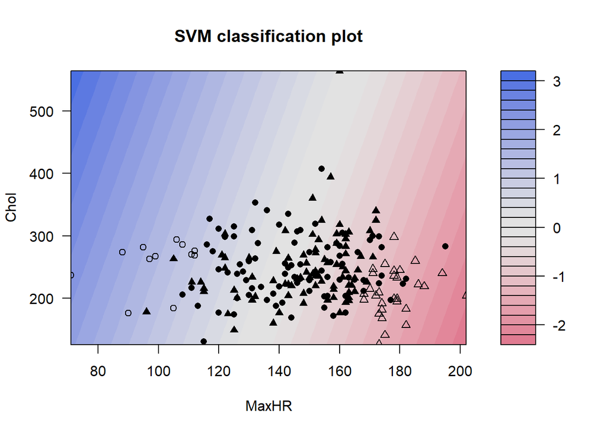

```r
plot(extract_fit_engine(m4),data=train)
```

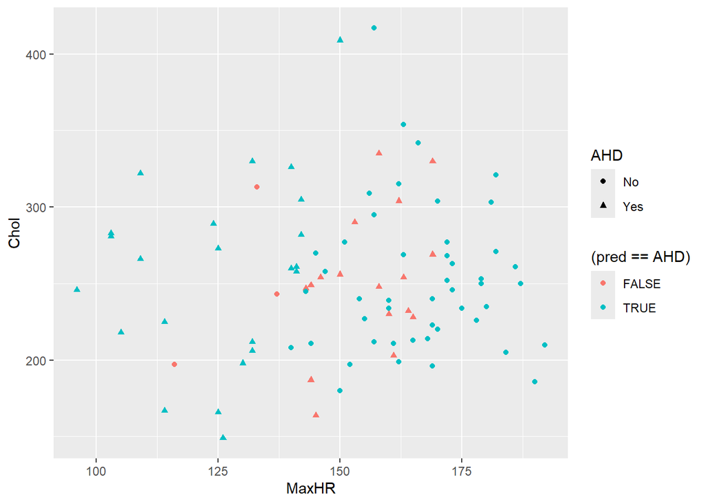

```r
ggplot(test|>mutate(pred=predict(m4,test)$.pred_class))+geom_point(aes(MaxHR,Chol,shape=AHD,color=(pred==AHD)))
```

## Polynomial kernel SVM

The function `ksvm` from kernlab allows to choose between many different kernels. One of the kernels is polynomial kernel
$$k(\mathbf{x},\mathbf{z})=(s\,\mathbf{x}\cdot
\mathbf{z}+c)^d,$$
where $s$ is the scale parameter, $c$ is offset and $d$ is degree of polynomials. The scale and degree parameters can be set through the command `svm_poly()` (parameters `scale_factor` and `degree`)

### Exercise 5

Consider the same classification problem as in Exercise 4. Find by cross-validation the best cost parameter (allowing `ksvm` to choose itself kernel scale and offset) in the case polynomial kernel with degree 2. What is the best value of accuracy on the validation set? Produce plots about the best model’s performance on the training and validation sets. What scale and offset were used? Look at what happens when scale is changed (try values 0.1 and 10)

```r
wf5_tune=workflow()|>add_recipe(rec4)|>add_model(svm_poly(mode="classification",cost=tune::tune(),engine="kernlab",degree=2))
Cgrid=data.frame(cost=10^seq(-3,3,length.out=10))
res5_tune=tune_grid(wf5_tune,splitted,grid=Cgrid,metrics=metric_set(accuracy))
show_best(res5_tune,metric="accuracy")
```

| cost | .metric | .estimator | mean | n | std_err | .config |
| --- | --- | --- | --- | --- | --- | --- |
| 0.4641589 | accuracy | binary | 0.6630435 | 1 | NA | Preprocessor1_Model05 |
| 2.1544347 | accuracy | binary | 0.6630435 | 1 | NA | Preprocessor1_Model06 |
| 10.0000000 | accuracy | binary | 0.6630435 | 1 | NA | Preprocessor1_Model07 |
| 46.4158883 | accuracy | binary | 0.6630435 | 1 | NA | Preprocessor1_Model08 |
| 215.4434690 | accuracy | binary | 0.6630435 | 1 | NA | Preprocessor1_Model09 |

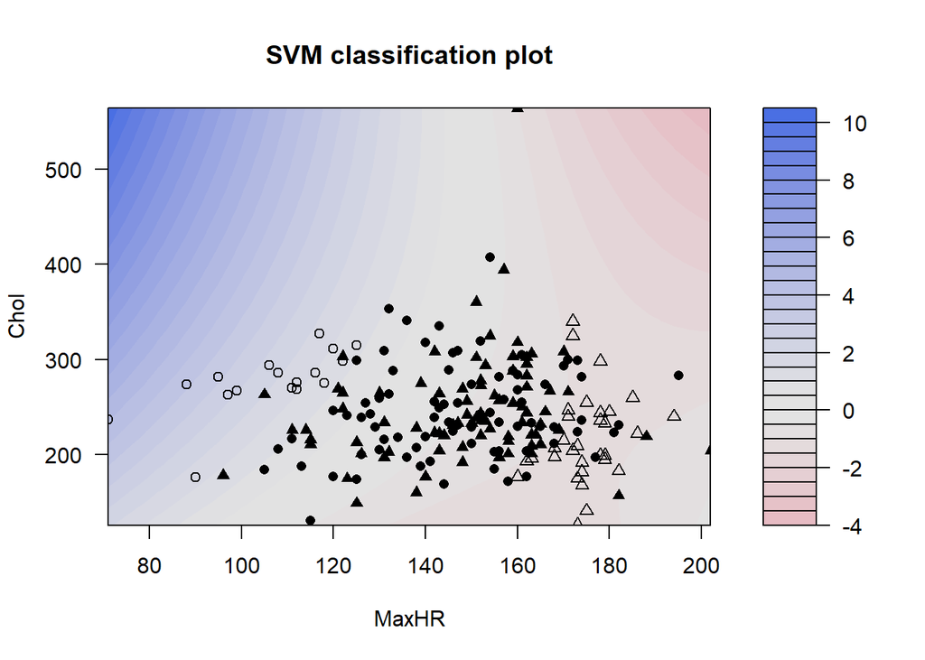

```r
wf5=wf5_tune|>finalize_workflow(select_best(res5_tune,metric="accuracy"))
m5=wf5|>fit(train)
plot(extract_fit_engine(m5),data=train)
```

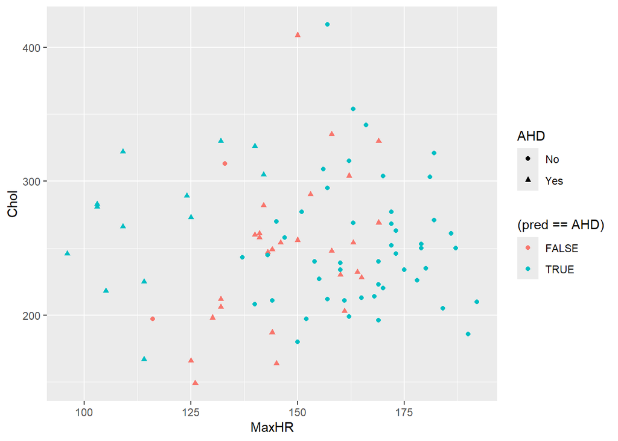

```r
ggplot(test|>mutate(pred=predict(m5,test)$.pred_class))+geom_point(aes(MaxHR,Chol,shape=AHD,color=(pred==AHD)))
```

```r
test|>mutate(pred=predict(m5,test)$.pred_class,AHD=factor(AHD))|>metrics(AHD,pred)
```

| .metric | .estimator | .estimate |
| --- | --- | --- |
| accuracy | binary | 0.6630435 |
| kap | binary | 0.2841365 |

[figure not shown]

```r
wf5.2=workflow()|>add_recipe(rec4)|>add_model(svm_poly(mode="classification",cost=0.02,engine="kernlab",degree=2,scale_factor=10))
m5.2=wf5.2|>fit(train)
plot(extract_fit_engine(m5.2),data=train)
```

### Exercise 6 Find by cross-validation the best combination of the cost parameter and degree (allowing `ksvm` to choose itself kernel scale and offset) in the case of using all variables and polynomial kernel by considering cost values 0.1,1,10 and degree values 2,3,4. Produce a graph showing observations on MaxHR-Chol plane together with actual class values and indicating by color the observations for which the model produced wrong predictions in the case of the best model and validation set.

```r
rec_all=recipe(AHD~.,data=train)|>step_impute_bag(Thal)|>step_impute_bag(Ca)|>step_dummy(all_nominal_predictors(), one_hot=TRUE)
wf6=workflow()|>add_recipe(rec_all)|>add_model(svm_poly(mode="classification",cost=tune(),engine="kernlab",degree=tune()))
grid=expand_grid(cost=c(0.1,1,10),degree=2:4)
res6_tune=tune_grid(wf6,splitted,grid=grid,metrics=metric_set(accuracy))
show_best(res6_tune,n=9)
```

| cost | degree | .metric | .estimator | mean | n | std_err | .config |
| --- | --- | --- | --- | --- | --- | --- | --- |
| 0.1 | 3 | accuracy | binary | 0.8369565 | 1 | NA | Preprocessor1_Model2 |
| 1.0 | 3 | accuracy | binary | 0.8369565 | 1 | NA | Preprocessor1_Model5 |
| 10.0 | 3 | accuracy | binary | 0.8369565 | 1 | NA | Preprocessor1_Model8 |
| 0.1 | 2 | accuracy | binary | 0.7826087 | 1 | NA | Preprocessor1_Model1 |
| 0.1 | 4 | accuracy | binary | 0.7826087 | 1 | NA | Preprocessor1_Model3 |
| 1.0 | 4 | accuracy | binary | 0.7826087 | 1 | NA | Preprocessor1_Model6 |
| 10.0 | 4 | accuracy | binary | 0.7826087 | 1 | NA | Preprocessor1_Model9 |
| 1.0 | 2 | accuracy | binary | 0.7608696 | 1 | NA | Preprocessor1_Model4 |
| 10.0 | 2 | accuracy | binary | 0.7608696 | 1 | NA | Preprocessor1_Model7 |

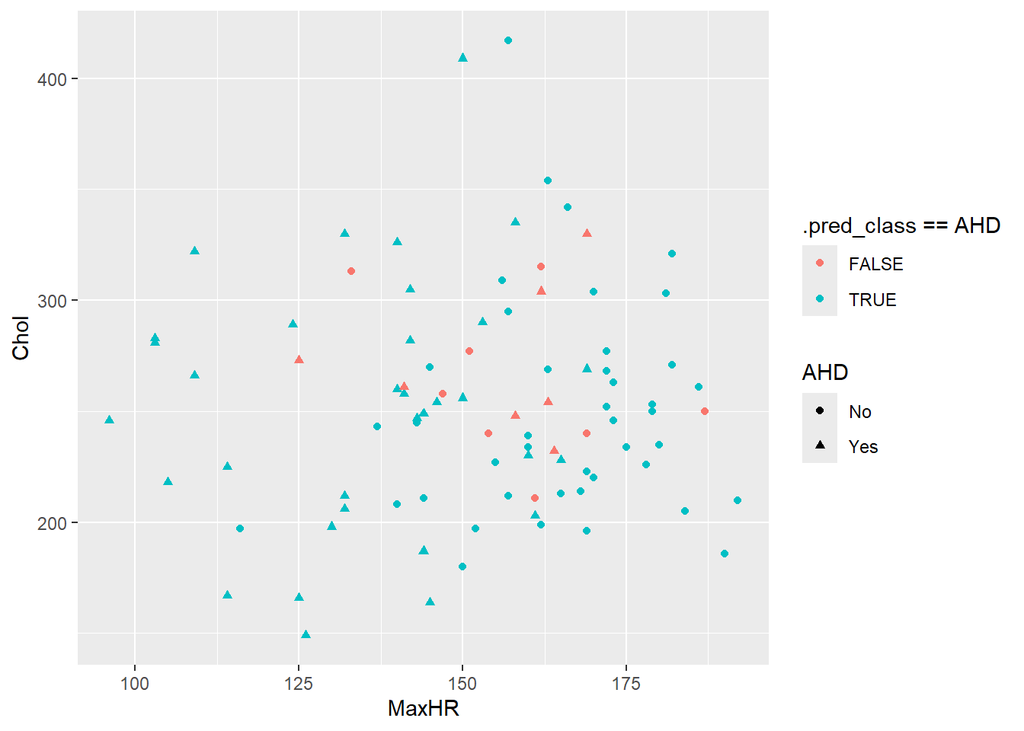

```r
wf6_final=finalize_workflow(wf6,select_best(res6_tune,metric="accuracy"))
results6=wf6_final|>fit(train)|>augment(new_data=test)
ggplot(data=results6)+geom_point(aes(x=MaxHR,y=Chol,shape=AHD,color=.pred_class==AHD))
```

## SVM with radial basis function kernel

The package `kernlab` uses definition
$$k(\mathbf{x},\mathbf{z})=\exp(-\sigma\|\mathbf{x}-\mathbf{z}\|^2),$$
so the parameter $\sigma$ is not the same as standard deviation in the density function of the normal distribution. This parameter (which name is `rbf_sigma`) can be set with the command `svm_rbf()`. A reasonable range for the values of it can be found by the command `sigest()`

### Exercise 7

Consider the same classification problem as in Exercise 4. Find by cross-validation the best cost parameter (allowing `ksvm` to choose itself the $\sigma$ for the kernel). What is the best value of accuracy on the validation set? Produce plots about the best model’s performance on the training and validation sets. What value of $\sigma$ was used? Look at what happens when $\sigma$ is changed.

```r
wf7_tune=workflow()|>add_recipe(rec4)|>add_model(svm_rbf(mode="classification",cost=tune::tune(),engine="kernlab"))
Cgrid=data.frame(cost=10^seq(-3,3,length.out=10))
res7_tune=tune_grid(wf7_tune,splitted,grid=Cgrid,metrics=metric_set(accuracy))
show_best(res7_tune,metric="accuracy")
```

| cost | .metric | .estimator | mean | n | std_err | .config |
| --- | --- | --- | --- | --- | --- | --- |
| 0.4641589 | accuracy | binary | 0.7500000 | 1 | NA | Preprocessor1_Model05 |
| 2.1544347 | accuracy | binary | 0.7391304 | 1 | NA | Preprocessor1_Model06 |
| 10.0000000 | accuracy | binary | 0.7282609 | 1 | NA | Preprocessor1_Model07 |
| 215.4434690 | accuracy | binary | 0.7065217 | 1 | NA | Preprocessor1_Model09 |
| 46.4158883 | accuracy | binary | 0.6956522 | 1 | NA | Preprocessor1_Model08 |

```r
wf7=wf7_tune|>finalize_workflow(select_best(res7_tune))
```

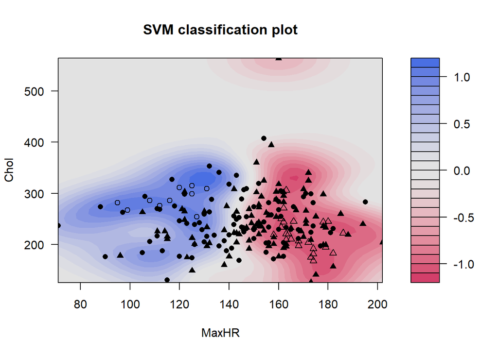

```r
m7=wf7|>fit(train)
plot(extract_fit_engine(m7),data=train)
```

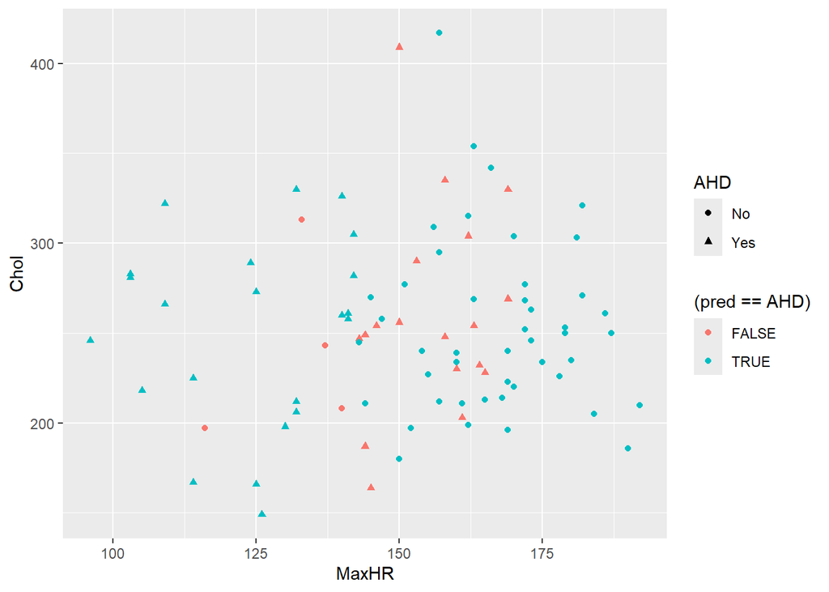

```r
ggplot(test|>mutate(pred=predict(m7,test)$.pred_class))+geom_point(aes(MaxHR,Chol,shape=AHD,color=(pred==AHD)))
```

```r
test|>mutate(pred=predict(m7,test)$.pred_class,AHD=factor(AHD))|>metrics(AHD,pred)
```

| .metric | .estimator | .estimate |
| --- | --- | --- |
| accuracy | binary | 0.7500000 |
| kap | binary | 0.4813725 |

### Exercise 8

Find the best SVM using Radial Basis functions which uses all predictors in the Heart data set. What is it’s accuracy on the validation set? Produce a graph on the MaxHR-Chol plane which shows, which observations were incorrectly predicted on the validation set.

```r
wf8_tune=workflow()|>add_recipe(rec_all)|>add_model(svm_rbf(mode="classification",cost=tune::tune(),engine="kernlab"))
Cgrid=data.frame(cost=10^seq(-3,3,length.out=10))
res8_tune=tune_grid(wf8_tune,splitted,grid=Cgrid,metrics=metric_set(accuracy))
show_best(res8_tune,metric="accuracy")
```

| cost | .metric | .estimator | mean | n | std_err | .config |
| --- | --- | --- | --- | --- | --- | --- |
| 46.415888 | accuracy | binary | 0.8804348 | 1 | NA | Preprocessor1_Model08 |
| 2.154435 | accuracy | binary | 0.8695652 | 1 | NA | Preprocessor1_Model06 |
| 215.443469 | accuracy | binary | 0.8695652 | 1 | NA | Preprocessor1_Model09 |
| 1000.000000 | accuracy | binary | 0.8695652 | 1 | NA | Preprocessor1_Model10 |
| 10.000000 | accuracy | binary | 0.8586957 | 1 | NA | Preprocessor1_Model07 |

```r
wf8=wf8_tune|>finalize_workflow(select_best(res8_tune))
```

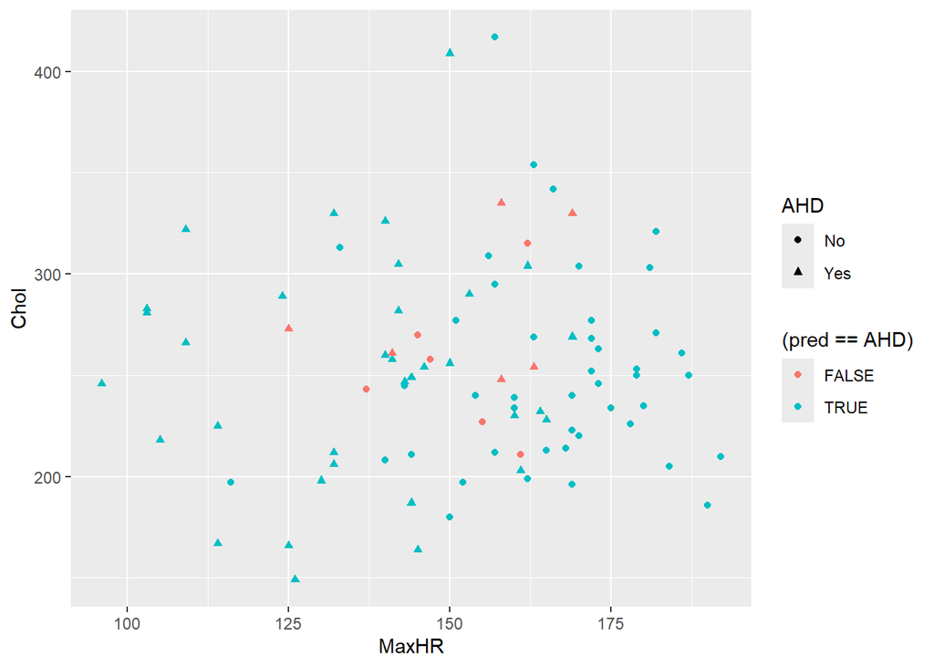

```r
m8=wf8|>fit(train)
ggplot(test|>mutate(pred=predict(m8,test)$.pred_class))+geom_point(aes(MaxHR,Chol,shape=AHD,color=(pred==AHD)))
```